# Abundance (cumulative and *P. maniculatus*)

Kate

November 9, 2018

### Total abundance

**Total raw abundance per species, summed across all sites.**

- Although traps were primarily open at night, we can still include diurnal species (chipmunks, squirrels) in measures of relative abundance because traps were opened and closed at approximately the same time each day.
- Flying squirrels spend a significant amount of time foraging on the ground, so their capture was not a fluke.

| Family | Binomial | Individuals |
| --- | --- | --- |
| Cricetidae | Peromyscus maniculatus | 426 |
| Soricidae | Sorex trowbridgii | 34 |
| Sciuridae | Otospermophilus beecheyi | 23 |
| Cricetidae | Peromyscus boylii | 18 |
| Sciuridae | Neotamias quadrimaculatus | 17 |
| Sciuridae | Neotamias senex | 12 |
| Cricetidae | Neotoma fuscipes | 5 |
| Sciuridae | Neotamias amoenus | 4 |
| Sciuridae | Glaucomys sabrinus | 2 |
| Cricetidae | Peromyscus truei | 2 |
| Cricetidae | Reithrodontomys megalotis | 2 |

**Overall abundance of small mammals was consistent across fire severities.** The abundance of small mammals summed across all species and standardized by trapping effort did not differ significantly between fire severity treatments (Kruskal-Wallis $\chi^2$(2) = 5.3, p = 0.07, n = 9 for each).

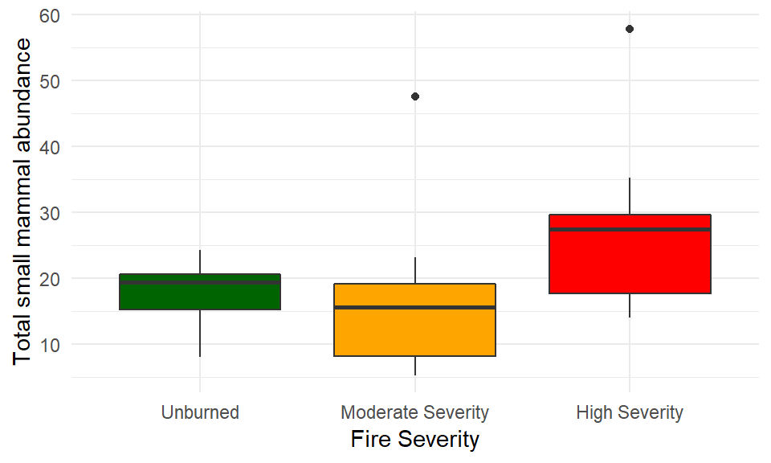

### Proportional abundance

**Small mammal community composition varied across fire severities.** The proportion of abundance by species is shown for each site across the fire severity gradient.

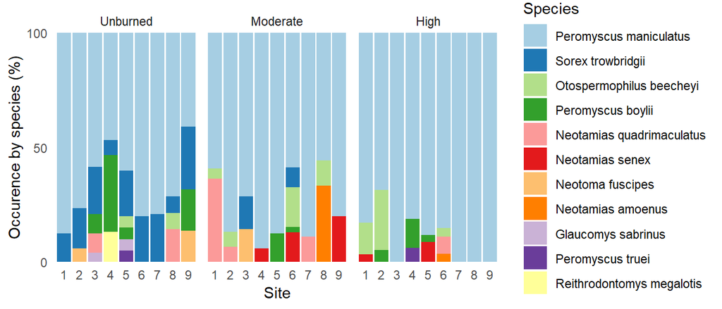

**Small mammal community varied across fire severities.** Habitat preferences for the 11 species of mammals, standardized by trapping effort.

- Paired figure with NMDS plot

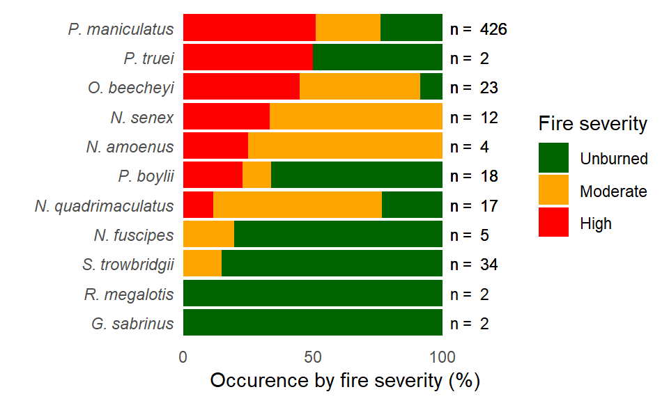

### *P. maniculatus* abundance

*P. maniculatus* abundance increased in high severity sites. Abundance, standardized by trapping effort, differed significantly between the three fire severity treatments (Kruskal-Wallis $\chi^2$(2) = 9.2, p < 0.01, n = 9 for each). Post-hoc analysis by Dunn’s test with a Bonferroni correction showed that mean density in high severity sites (mean = 25.2 indv) differed significantly from both unburned (11.8 indv) and mixed severity sites (12.4 indv) (pairwise p = 0.01 and 0.02, respectively).

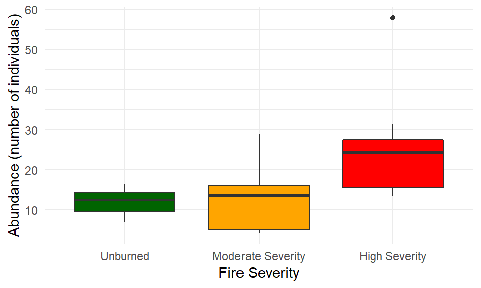